# Доклад

Тема “Фильтрация спама”

Бызова М. О. Кулябов Дмитрий Сергеевич. Доцент по кафедре систем телекоммуникаций. Доктор физико-математических наук по специальности 05.13.18 «Математическое моделирование, численные методы и комплексы программ». Профессор кафедры прикладной информатики и теории вероятностей РУДН. Заведующий сектором Управления информационно-технологического обеспечения, слаботочных и телекоммуникационных систем РУДН (по совместительству).

Российский университет дружбы народов

2025-10-13

# Вводная часть

## Докладчик

- Бызова Мария Олеговна
- Студент
- Российский университет дружбы народов
- 1132236129@pfur.ru

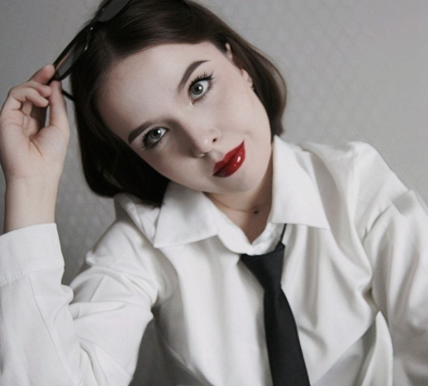

## Актуальность

Актуальность темы борьбы со спамом обусловлена повсеместным распространением цифровой коммуникации и, как следствие, растущим объемом нежелательной корреспонденции.

Проблема заключается в необходимости разработки эффективных и точных методов фильтрации спама, способных противостоять постоянно усложняющимся тактикам его распространения, предотвращая финансовые потери и риски для пользователей.

## Объект и предмет исследования

Объектом исследования данного доклада являются системы и методы фильтрации нежелательной корреспонденции (спама) в цифровых каналах коммуникации.

Предмет исследования – алгоритмические и программные средства автоматического распознавания и блокировки спам-сообщений, а также критерии их классификации и оценки эффективности.

## Цель

Целью данного доклада является анализ современных методов и алгоритмов фильтрации спама, а также систематизация подходов к их применению для обеспечения эффективной защиты пользователей от нежелательной и вредоносной корреспонденции.

## Задачи исследования

Задачи исследования включают анализ эволюции и классификацию видов спама, изучение принципов работы и алгоритмов спам-фильтров, а также оценку эффективности и сравнительных характеристик различных методов противодействия спам-рассылкам.

## Материалы, методы и инструменты исследования

Учебные пособия и книги, интернет-ресурсы и аналитика.

# Введение

## Введение

Современная цифровая коммуникация столкнулась с масштабной проблемой спама, создающей неудобства и угрозы безопасности. Эффективная фильтрация нежелательной корреспонденции стала критически важной задачей.

Ключевые аспекты проблемы:

- Растущий объем спама.
- Усложнение методов рассылки.
- Финансовые потери и риски заражения ПО.

# Спам

## Понятие спама

Спам — это **анонимная, безадресная, массовая и незапрошенная** рассылка почтовых сообщений.

Эволюция термина:

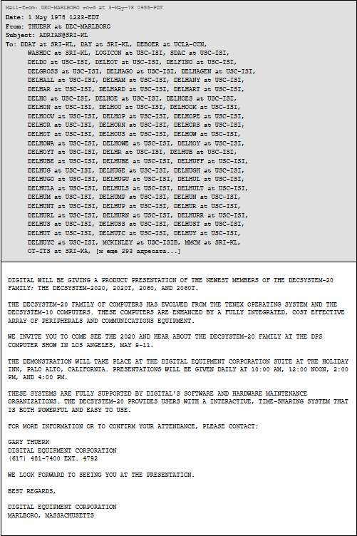

Первое спам-письмо в истории

## Классификация спама

**Основные категории спама**:

1. Рекламный спам и антирекламный спам.
2. “Нигерийские письма”.
3. Фишинг.
4. Цепные письма (“Письма счастья”)
5. Массовая рассылка для вывода почтовой системы из строя.
6. Массовая рассылка писем, содержащих компьютерные вирусы.

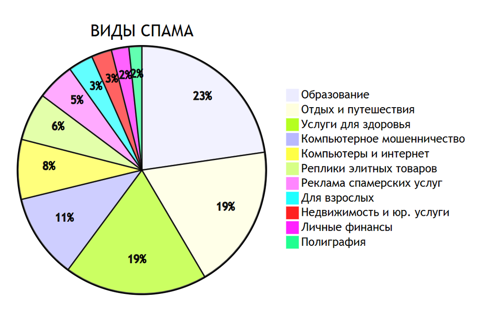

Основные тематики спама

# Организация и технологические основы спам-рассылок

## Организация спам-рассылок

Технологическая цепочка:

1. Сбор баз адресов:
   - Автоматический подбор.
   - Сканирование открытых источников.
   - Кража через вредоносное ПО.
2. Инфраструктура доставки:
   - Арендованные серверы.
   - Открытые релеи и прокси.
   - Ботнеты — наиболее эффективный канал.
3. Программное обеспечение:
   - Генерация уникального контента.
   - Подделка заголовков.
   - Методы противодействия фильтрам.

# Методы борьбы со спамом

## Методы борьбы со спамом

Комплексный подход включает три уровня мер:

1. **Нормативно-правовые:** привлечение спамеров к ответственности.
2. **Организационные:** цифровая гигиена пользователей.
3. **Программно-технические:** использование анти-спам фильтров.

## Фильтрация на стороне провайдера

**Принцип работы: очистка почтового трафика на серверах провайдера до доставки конечным пользователям.**

**Технологии:**

- RBL-списки (Realtime Blackhole List - черные списки IP)
- Распределенные методы анализа
- DNS-проверки отправителей
- Статистический анализ трафика

## Фильтрация на уровне провайдера

[figure not shown]

Рисунок 1: Схема фильтрации спама провайдерами

## RBL-фильтрация (Realtime Blackhole List)

**Realtime Blackhole List** - черные списки IP. **Принцип работы: Проверка IP-адреса отправителя по спискам известных спамеров через DNS-запрос.**

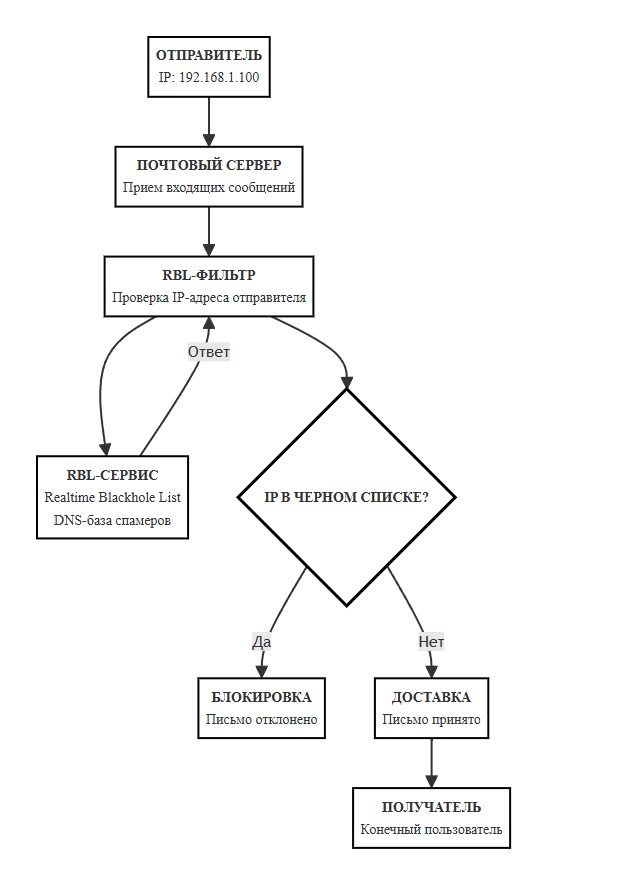

Рисунок 2: Схема работы фильтрации спама с использованием RBL-сервисов

## Распределённые методы

Принцип работы: Агрегация данных о спаме из множества источников (ловушки, голосования, анализ трафика).

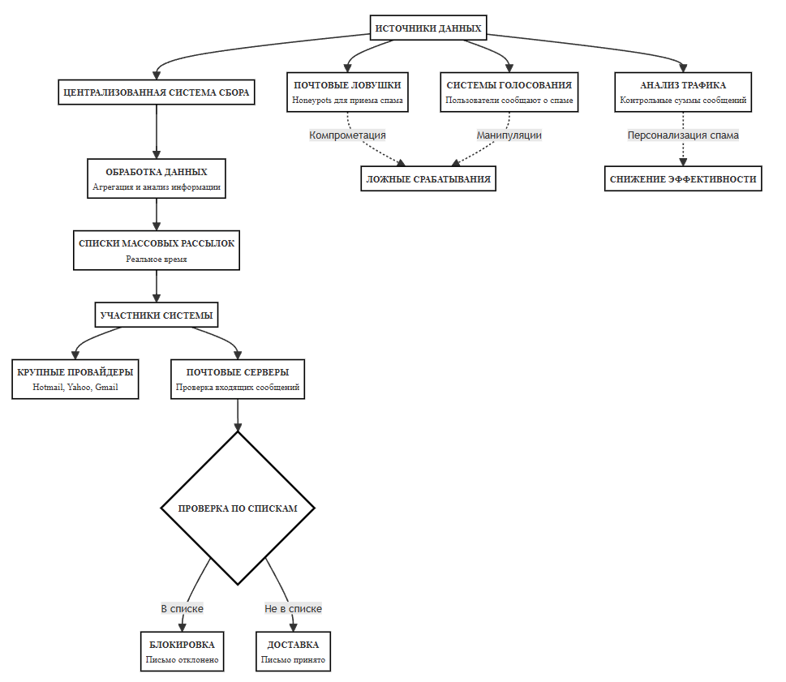

Рисунок 3: Схема работы распределённых методов обнаружения спама

## Фильтрация на корпоративном сервере

**Принцип работы: защита почтовой инфраструктуры организации с обработкой трафика до сотрудников.**

**Технологии:**

- Байесовские фильтры
- Машинное обучение
- Персонализированные политики
- Адаптация под бизнес-процессы

## Фильтрация на корпоративном сервере

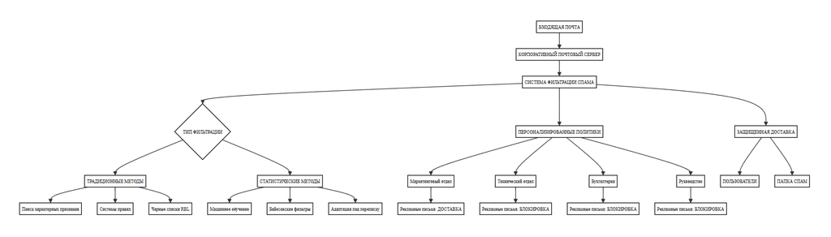

Рисунок 4: Схема серверной корпоративной фильтрации спама

## Байесовская фильтрация

Принцип работы: Вычисление вероятности того, что письмо является спамом, на основе анализа слов (теорема Байеса).

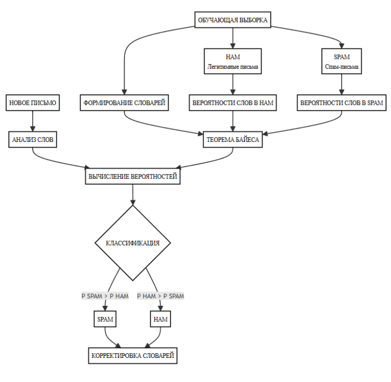

Схема байесовского метода фильтрации спама

## Байесовская фильтрация. Конкретный пример

Формула: P(SPAM|Слова) = [P(Слова|SPAM) × P(SPAM)] / P(Слова)

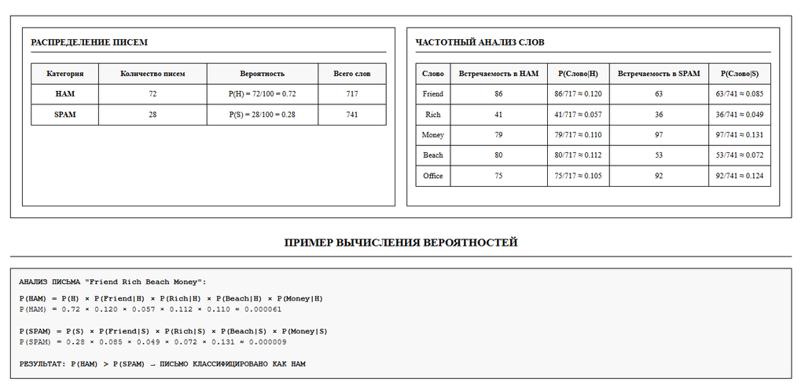

Рисунок 5: Конкретный пример работы байесовского метода фильтрации спама

## Фильтрация на стороне клиента

**Принцип работы: установка антиспам-решений на устройствах пользователей для персонализированной защиты.**

**Технологии:**

- Интеграция с почтовыми клиентами
- Черные/белые списки
- Эвристические алгоритмы
- Интерактивное обучение

## Фильтрация на стороне клиента

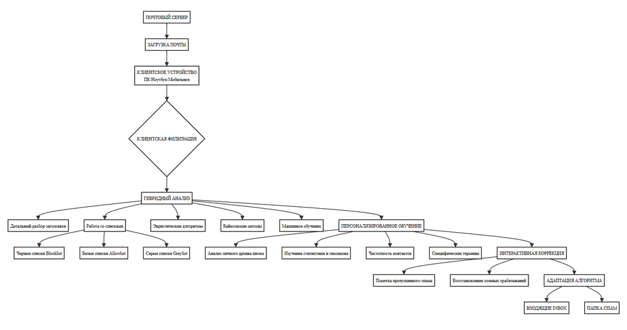

Рисунок 6: Схема фильтрации на стороне клиента

# Профилактика спама

## Профилактика спама

**Правила цифоровой гигиены:**

1. Разделение ящиков
2. Сложные имена
3. Одноразовые адреса
4. Ротация адресов
5. Никаких ответов на подозрительные сообщения
6. Проверка источников
7. Антиспам-фильтры
8. Мониторинг утечек

# Выводы

## Выводы

Таким образом, для эффективной борьбы с эволюционирующим спамом необходима комплексная, многоуровневая защита, сочетающая статистические методы фильтрации, обучение пользователей кибербезопасности, машинное обучение и международное сотрудничество.

# Список литературы

## Список литературы

- Арутюнов В. В. «Спам: история возникновения и противодействие его распространению» // Вестник Московского финансово-юридического университета, 2012, №1, с. 44–48.
- Попкова А. А. «Спам — разновидность информационной угрозы» // Сборник статей по итогам Международной научно-практической конференции, 2017, с. 183–185.
- Копырулина О. А., Устюжанин Е. В. «Меры борьбы со спамом» // Вестник современных исследований, 2018, №9.3 (24), с. 267–268.
- Рожков Г. Г. «Методы борьбы с почтовым спамом» // Известия Орловского государственного технического университета, Серия: Информационные системы и технологии, 2006, №1–4, с. 180–187.
- Ляпидов К. В. «Спам: понятие, виды, последствия и методы противодействия» // Информационное право, 2013, №5, с. 29–32.